# Modelo SARIMA: Caso Spotify 2016-2025

### No autocorrelación temporal

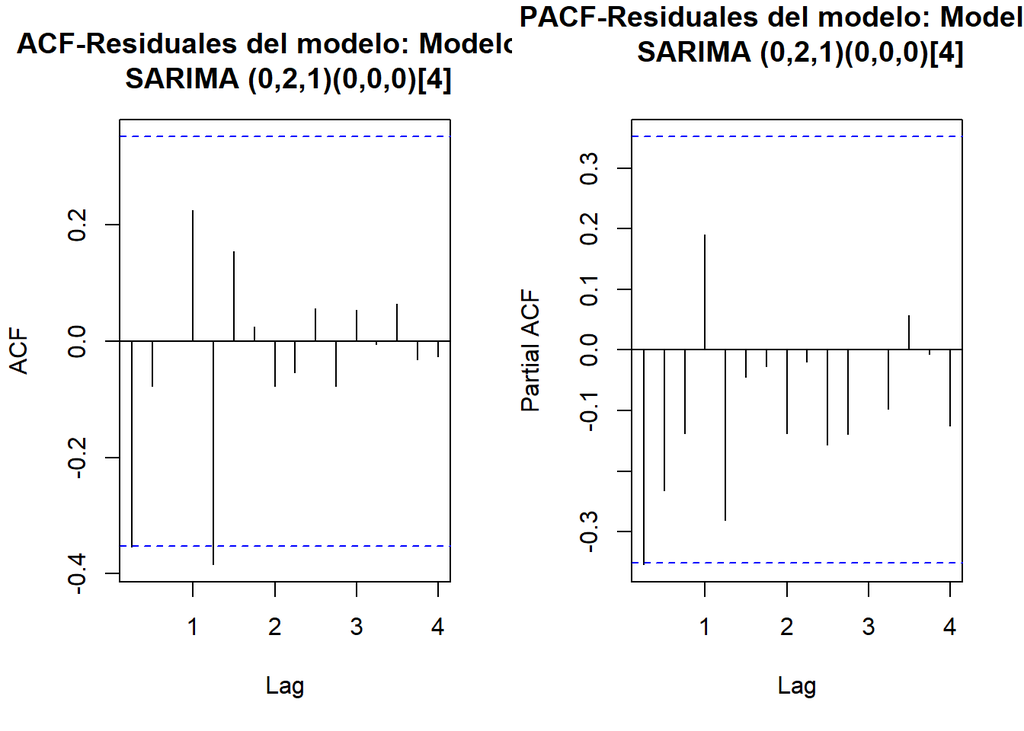

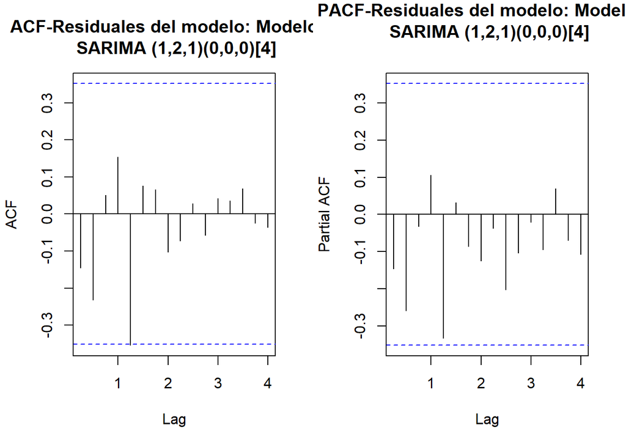

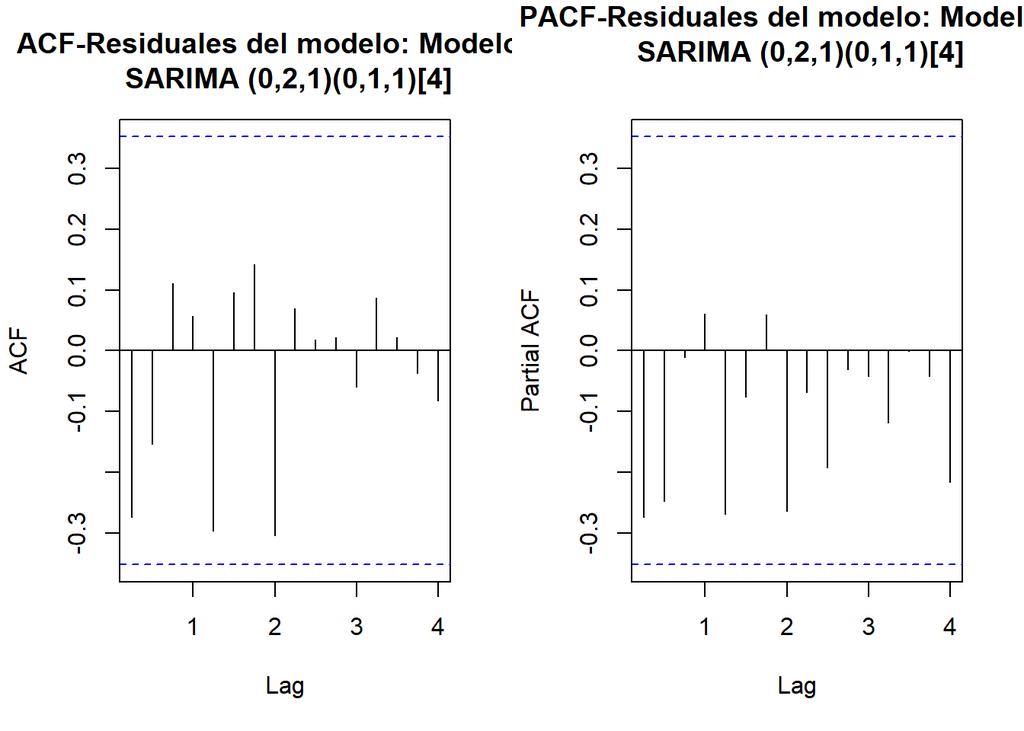

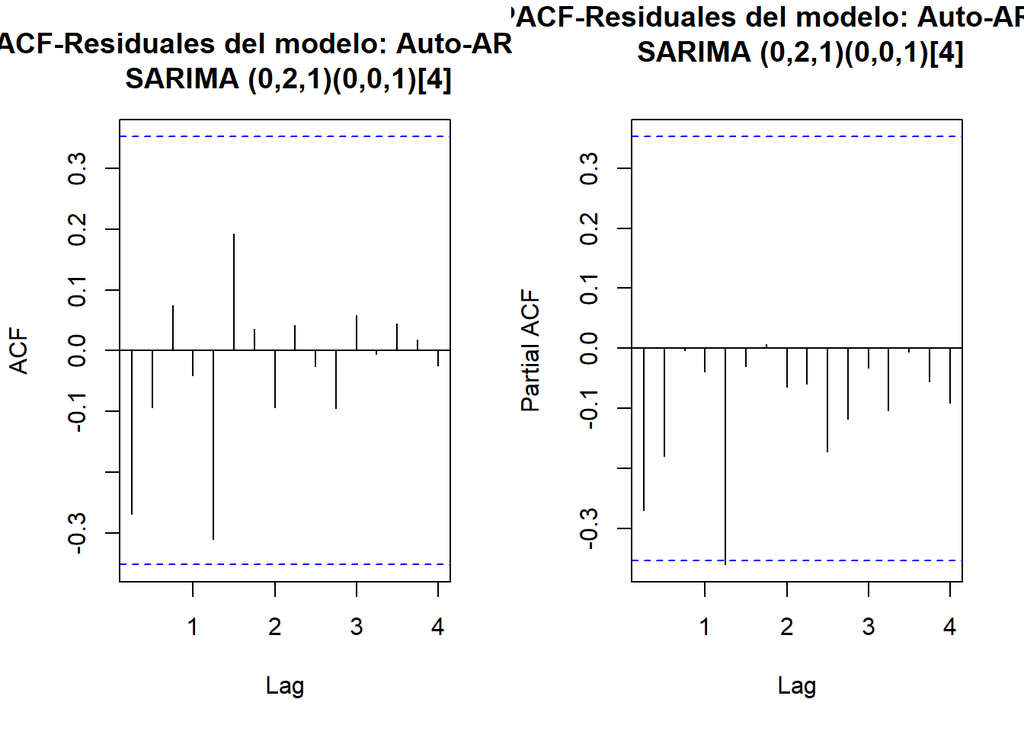

```r
for (i in seq_along(modelosentrenados)) {

  # Criterio gráfico
  opcion = par(mfrow=c(1,2))

  # 1. Extraer el vector de órdenes
  # El orden en $arma es: [p, q, P, Q, s, d, D]
  o <- modelosentrenados[[i]]$arma

  # 2. Construir la etiqueta de los órdenes
  # Formato: (p,d,q)(P,D,Q)[s]
  orden_txt <- paste0("(", o[1], ",", o[6], ",", o[2], ")",
                      "(", o[3], ",", o[7], ",", o[4], ")[", o[5], "]")
  # gráficos
  acf(modelosentrenados[[i]]$residuals,lag.max=16, main = paste("ACF-Residuales del modelo:", names(modelosentrenados)[i], "\n SARIMA", orden_txt))

  pacf(modelosentrenados[[i]]$residuals,lag.max=16, main = paste("PACF-Residuales del modelo:", names(modelosentrenados)[i], "\n SARIMA", orden_txt))

}
```

**Resultados ACF y PACF de los residuales:**

❌Modelo 1:

- De acuerdo con el gráfico ACF, persiste una autocorrelación temporal de los residuales en los rezagos 1 y 5. Esto sugiere que el modelo aún no captura la totalidad de la información que pueden aportar los valores pasados de la variable objetivo. En este modelo se aprecia que persiste una autocorrelación parcial de los residuales al rezago N° 1.

🤏Modelo 2:

- De acuerdo con el gráfico ACF, persiste una autocorrelación temporal de los residuales en el rezago 5 (sale por un margen mínimo de la banda de significancia). Esto sugiere que el modelo aún no captura la totalidad de la información que pueden aportar los valores pasados de la variable objetivo. En este modelo se aprecia que no persiste una autocorrelación parcial de los residuales a ningún rezago.

✅Modelo 3:

- De acuerdo con el gráfico ACF, no persisten autocorrelaciones temporales significativas de los residuales con los valores pasados. Esto sugiere que el modelo captura adecuadamente la totalidad de la información que pueden aportar los valores pasados de la variable objetivo. En este modelo se aprecia que no persiste una autocorrelación parcial de los residuales a ningún rezago.

❌Modelo autoarima:

- De acuerdo con el gráfico ACF, no persisten autocorrelaciones temporales significativas de los residuales con los valores pasados. Esto sugiere que el modelo captura adecuadamente la totalidad de la información que pueden aportar los valores pasados de la variable objetivo. Sin embargo, en este modelo se aprecia que persiste una autocorrelación parcial de los residuales al rezago N° 5.

```r
for (i in seq_along(modelosentrenados)) {

  # 1. Extraer el vector de órdenes
  # El orden en $arma es: [p, q, P, Q, s, d, D]
  o <- modelosentrenados[[i]]$arma

  # 2. Construir la etiqueta de los órdenes
  # Formato: (p,d,q)(P,D,Q)[s]
  orden_txt <- paste0("(", o[1], ",", o[6], ",", o[2], ")",
                      "(", o[3], ",", o[7], ",", o[4], ")[", o[5], "]")

cat("\n========================================================\n")
  cat("DIAGNÓSTICO:", names(modelosentrenados)[i], "SARIMA", orden_txt, "\n")
  cat("========================================================\n")

  # 3. Prueba de Ljung-Box (Ahora con print para que se visualicen)
  print(Box.test(residuals(modelosentrenados[[i]]), lag = 10, type = "Ljung"))
  print(Box.test(residuals(modelosentrenados[[i]]), lag = 15, type = "Ljung"))
  print(Box.test(residuals(modelosentrenados[[i]]), lag = 24, type = "Ljung"))

}
```

```
##
## ========================================================
## DIAGNÓSTICO: Modelo 1 SARIMA (0,2,1)(0,0,0)[4]
## ========================================================
##
##  Box-Ljung test
##
## data:  residuals(modelosentrenados[[i]])
## X-squared = 13.79, df = 10, p-value = 0.1828
##
##
##  Box-Ljung test
##
## data:  residuals(modelosentrenados[[i]])
## X-squared = 14.569, df = 15, p-value = 0.4829
##
##
##  Box-Ljung test
##
## data:  residuals(modelosentrenados[[i]])
## X-squared = 15, df = 24, p-value = 0.9208
##
##
## ========================================================
## DIAGNÓSTICO: Modelo 2 SARIMA (1,2,1)(0,0,0)[4]
## ========================================================
##
##  Box-Ljung test
##
## data:  residuals(modelosentrenados[[i]])
## X-squared = 9.7249, df = 10, p-value = 0.4649
##
##
##  Box-Ljung test
##
## data:  residuals(modelosentrenados[[i]])
## X-squared = 10.372, df = 15, p-value = 0.7957
##
##
##  Box-Ljung test
```

[output cut: 32 more lines]

```
##
## data:  residuals(modelosentrenados[[i]])
## X-squared = 8.9218, df = 10, p-value = 0.5395
##
##
##  Box-Ljung test
##
## data:  residuals(modelosentrenados[[i]])
## X-squared = 9.7046, df = 15, p-value = 0.8379
##
##
##  Box-Ljung test
##
## data:  residuals(modelosentrenados[[i]])
## X-squared = 10.11, df = 24, p-value = 0.9941
```

**Resultados prueba estadística Ljung-Box:**

- Para todos los modelos se tiene que los p-valores de la prueba a 10, 15 y 24 rezagos, son mayores a 0.05. Estos valores no permiten rechazar la hipótesis nula (H_0: los datos se distribuyen de forma independiente). Por lo tanto, es posible concluir que en todos los modelos los residuales se distribuyen de manera independiente.
- Estos resultados se pueden visualizar en las gráficas que se muestran a continuación.

```r
# Gráficos de la prueba Ljung-Box
for (i in seq_along(modelosentrenados)) {

  # 1. Extraer el vector de órdenes
  # El orden en $arma es: [p, q, P, Q, s, d, D]
  o <- modelosentrenados[[i]]$arma

  # 2. Construir la etiqueta de los órdenes
  # Formato: (p,d,q)(P,D,Q)[s]
  orden_txt <- paste0("(", o[1], ",", o[6], ",", o[2], ")",
                      "(", o[3], ",", o[7], ",", o[4], ")[", o[5], "]")

  par(mar = c(3, 3, 2, 1), mgp = c(2, 0.7, 0))
  par(cex = 0.6) # Reduce todo el texto al 60%
  par(oma = c(0, 0, 3, 0))

  # 3. Diagnósticos de la serie de tiempo
  tsdiag(modelosentrenados[[i]], gof.lag=24)

  mtext(paste(names(modelosentrenados)[i], ". SARIMA", orden_txt), side = 3, line = 1, outer = TRUE, font = 2, cex = 1.1)

}
```

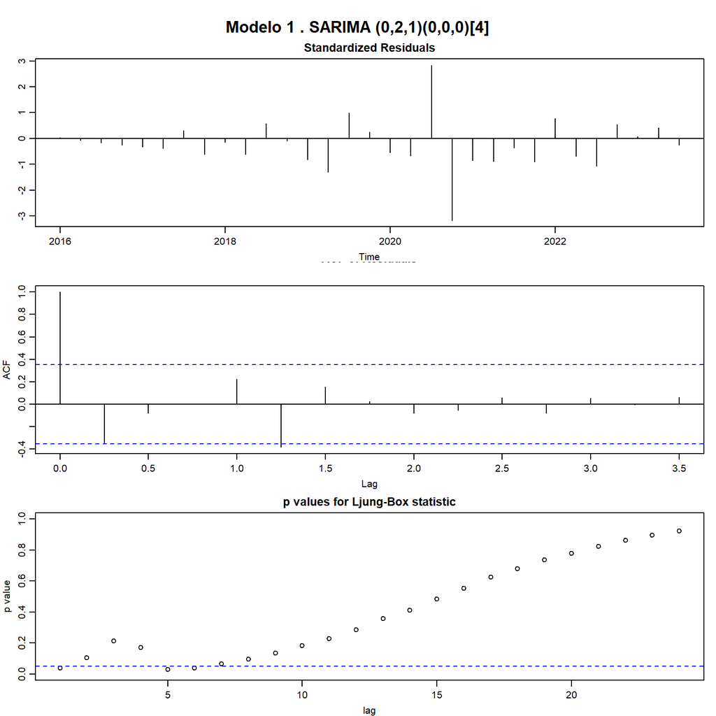

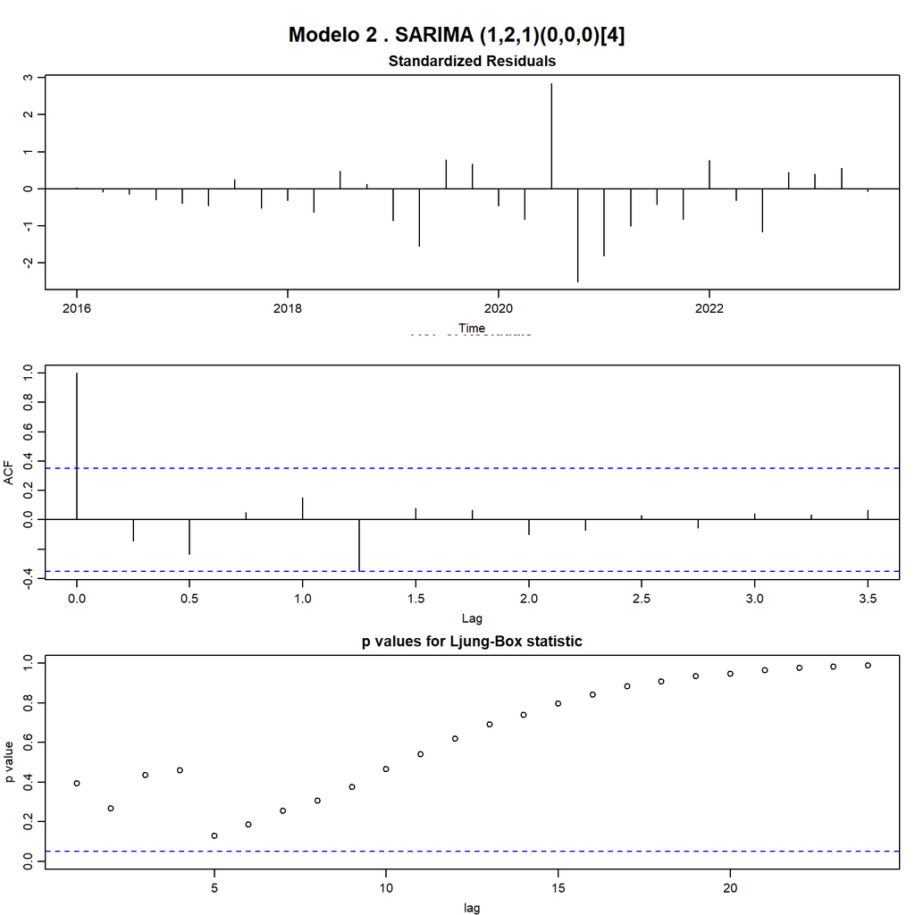

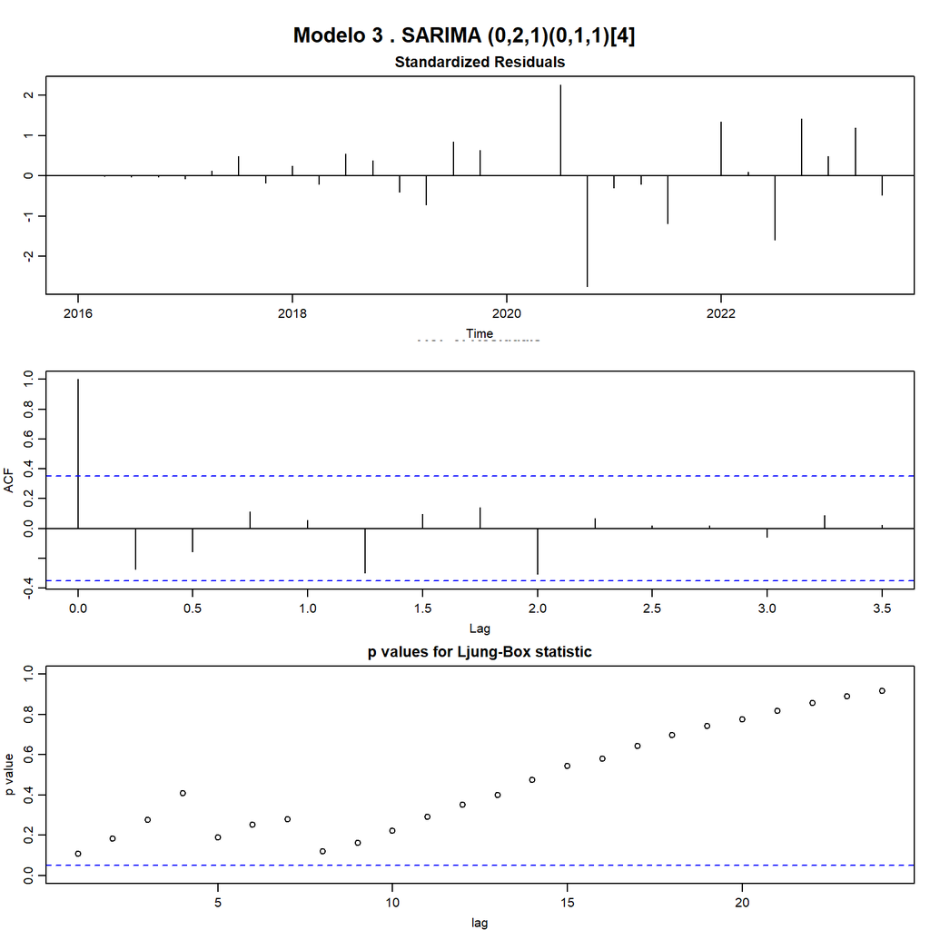

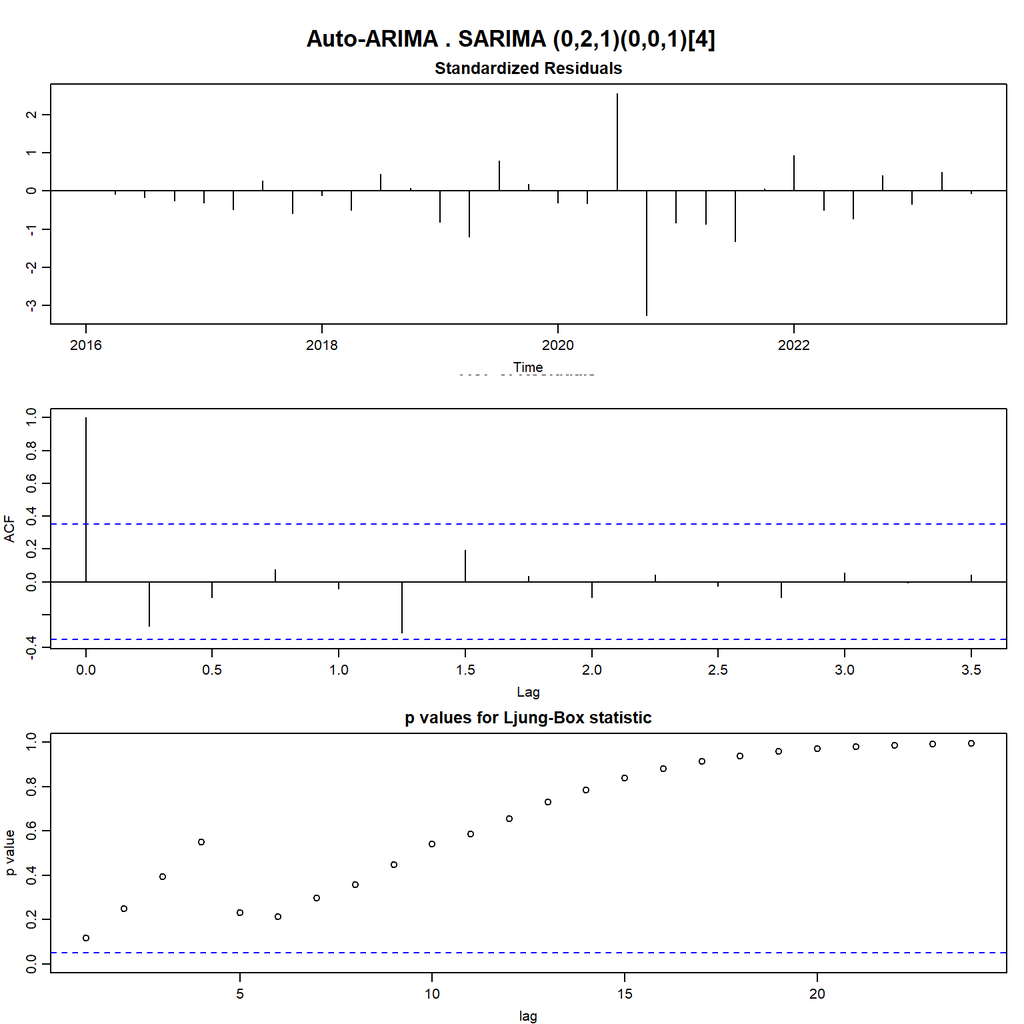

### Residuos estándar como ruido blanco

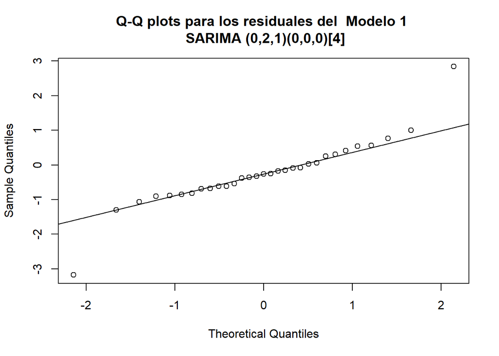

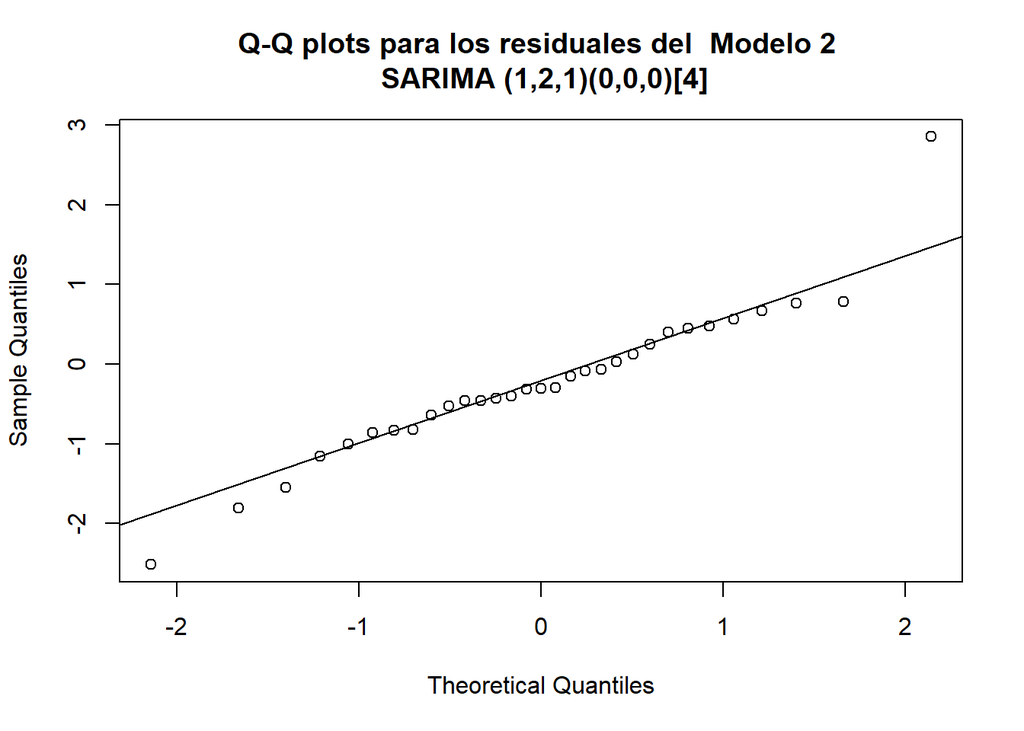

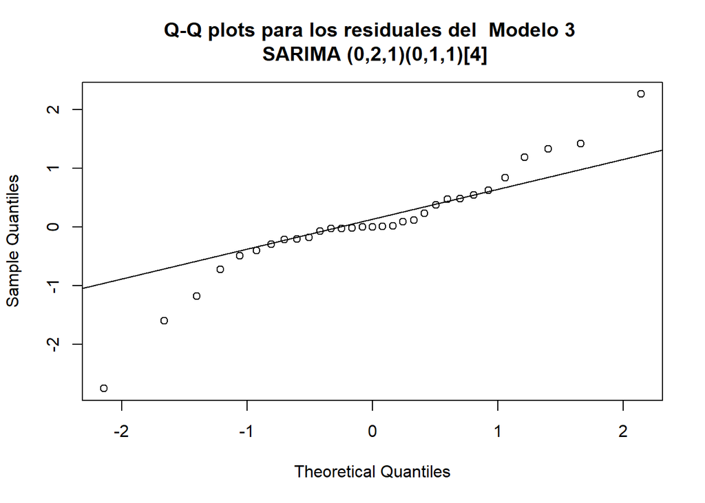

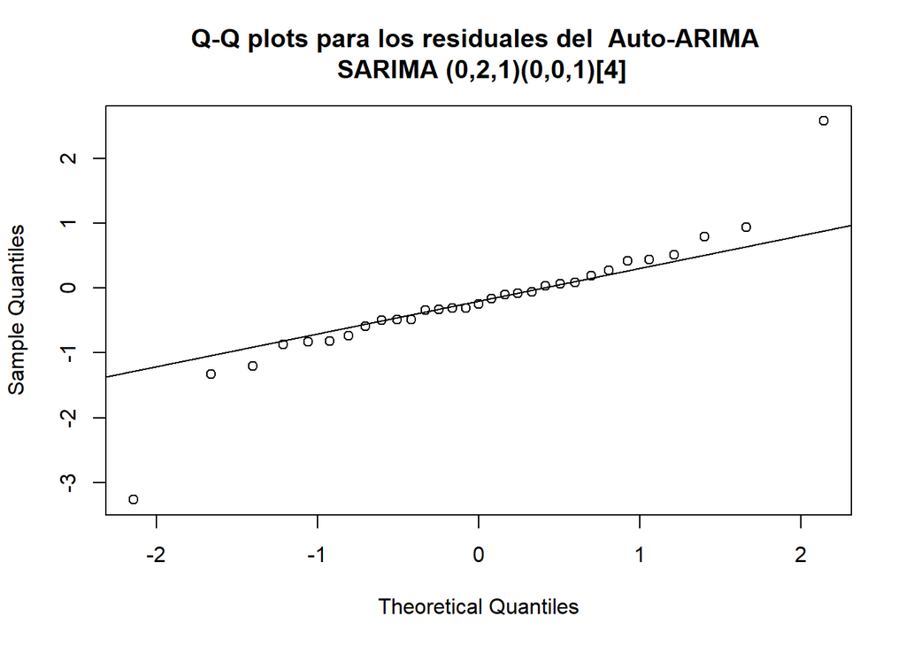

```r
for (i in seq_along(modelosentrenados)) {

  # 1. Extraer el vector de órdenes
  # El orden en $arma es: [p, q, P, Q, s, d, D]
  o <- modelosentrenados[[i]]$arma

  # 2. Construir la etiqueta de los órdenes
  # Formato: (p,d,q)(P,D,Q)[s]
  orden_txt <- paste0("(", o[1], ",", o[6], ",", o[2], ")",
                      "(", o[3], ",", o[7], ",", o[4], ")[", o[5], "]")

  # 3. Gráficos
  qqnorm(rstandard(modelosentrenados[[i]]), main = paste("Q-Q plots para los residuales del ", names(modelosentrenados)[i], "\n SARIMA", orden_txt))
  qqline(rstandard(modelosentrenados[[i]]))

  # mtext(paste(names(modelosentrenados)[i], ". SARIMA", orden_txt), side = 3, line = 1, outer = TRUE, font = 2, cex = 1.1)

}
```

**Resultados gráficos de cuartiles (QQ-plots):**

```r
for (i in seq_along(modelosentrenados)) {

  # 1. Extraer el vector de órdenes
  # El orden en $arma es: [p, q, P, Q, s, d, D]
  o <- modelosentrenados[[i]]$arma

  # 2. Construir la etiqueta de los órdenes
  # Formato: (p,d,q)(P,D,Q)[s]
  orden_txt <- paste0("(", o[1], ",", o[6], ",", o[2], ")",
                      "(", o[3], ",", o[7], ",", o[4], ")[", o[5], "]")

cat("\n========================================================\n")
  cat("DIAGNÓSTICO:", names(modelosentrenados)[i], "SARIMA", orden_txt, "\n")
  cat("========================================================\n")


  print(shapiro.test(rstandard(modelosentrenados[[i]])))

}
```

```
##
## ========================================================
## DIAGNÓSTICO: Modelo 1 SARIMA (0,2,1)(0,0,0)[4]
## ========================================================
##
##  Shapiro-Wilk normality test
##
## data:  rstandard(modelosentrenados[[i]])
## W = 0.88825, p-value = 0.003714
##
##
## ========================================================
## DIAGNÓSTICO: Modelo 2 SARIMA (1,2,1)(0,0,0)[4]
## ========================================================
##
##  Shapiro-Wilk normality test
##
## data:  rstandard(modelosentrenados[[i]])
## W = 0.93683, p-value = 0.06745
##
##
## ========================================================
## DIAGNÓSTICO: Modelo 3 SARIMA (0,2,1)(0,1,1)[4]
## ========================================================
##
##  Shapiro-Wilk normality test
##
## data:  rstandard(modelosentrenados[[i]])
## W = 0.92385, p-value = 0.0299
##
##
## ========================================================
## DIAGNÓSTICO: Auto-ARIMA SARIMA (0,2,1)(0,0,1)[4]
## ========================================================
##
##  Shapiro-Wilk normality test
##
## data:  rstandard(modelosentrenados[[i]])
## W = 0.88564, p-value = 0.003217
```

**Resultados prueba Shapiro-Wilk:**

- Sólamente en el modelo N° 2, se tiene que el p-valor de la prueba Shapiro-Wilk es mayor a 0.05 y no permite rechazar la hipótesis nula de que los residuales estándar tienen una distribución normal ( $H_0:\text{la población está distribuida normalmente}$ )
- Estos resultados son contradictorios con las pruebas realizadas hasta el momento y pueden estar influenciados por el cambio brusco de los valores que se dió entre el trimestre 2020-III y 2020-IV.

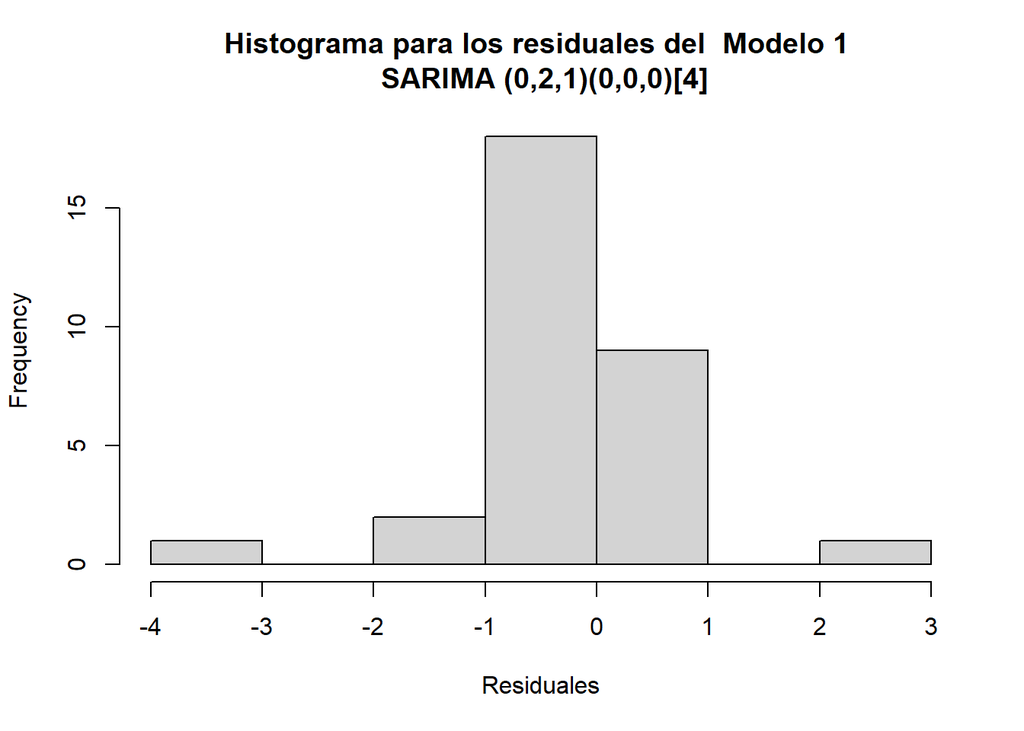

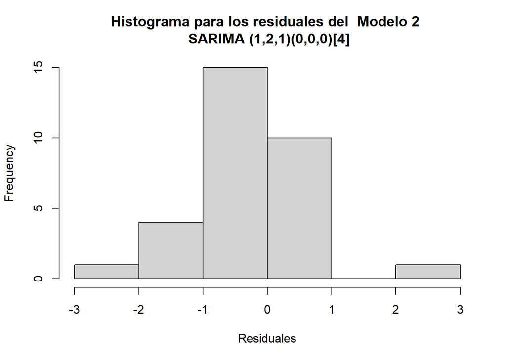

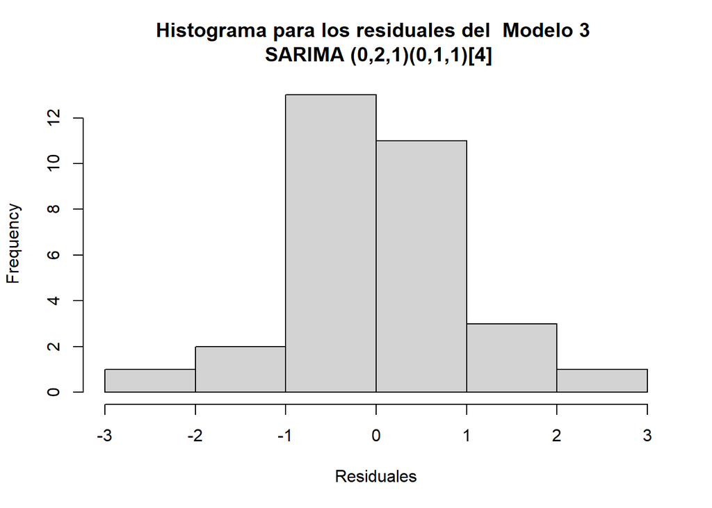

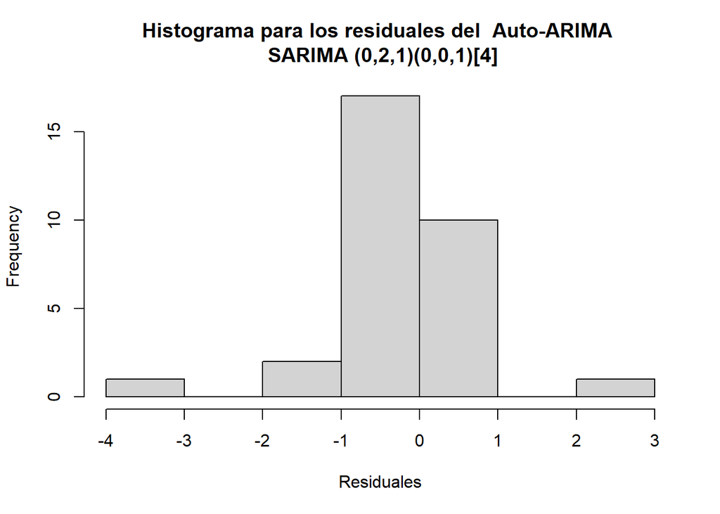

```r
for (i in seq_along(modelosentrenados)) {

  # 1. Extraer el vector de órdenes
  # El orden en $arma es: [p, q, P, Q, s, d, D]
  o <- modelosentrenados[[i]]$arma

  # 2. Construir la etiqueta de los órdenes
  # Formato: (p,d,q)(P,D,Q)[s]
  orden_txt <- paste0("(", o[1], ",", o[6], ",", o[2], ")",
                      "(", o[3], ",", o[7], ",", o[4], ")[", o[5], "]")

  # 3. Gráfico
  hist(rstandard(modelosentrenados[[i]]), main = paste("Histograma para los residuales del ", names(modelosentrenados)[i], "\n SARIMA", orden_txt), xlab = "Residuales")

}
```

## Modelos SARIMA seleccionados

- Teniendo en cuenta que los modelos N° 1 y 4 cumplieron con la mayoría de los supuestos sobre los residuales, a excepción de la no autocorrelación temporal de los residuos (evidenciado en los correlogramas de los residuales), se escogen los modelos N° 2 y 3.
- A estos modelos se les aplicarán pruebas de calidad de los pronósticos dentro de la muestra (2016-I a 2023-III) y fuera de la muestra (2023-IV a 2025-III).

## Pruebas sobre pronósticos

Anotaciones sobre el reescalado de la variable objetivo de la escala logarítmica diferenciada dos veces, a la escala original (Millones de usuarios):

- En esta sección se hará uso de las funciones fitted(modelo) y predict(modelo), las cuales devuelven los valores ya “re-integrados”. Es decir, ya están en niveles de serie_log, no en las dos diferencias con que se estimaron los modelos.
- Debido a que la función exponencial es convexa, la transformación inversa simple tiende a subestimar el valor real. Para corregirlo, se suma la mitad de la varianza del error $\sigma^2/2$ antes de aplicar la exponencial (corrección de Jensen).
  - De acuerdo con Hyndman & Athanasopoulos (*Forecasting: Principles and Practice*), si $ln(Y) \sim N(\mu, \sigma^2)$, entonces la media de la serie original es $E[Y] = exp(\mu + \sigma^2/2)$.

### Pruebas al modelo 2

#### Período dentro de la muestra

```r
m2.predicted_log <- serie_log - modelo2$residuals
m2.predicted_log
```

```
##          Qtr1     Qtr2     Qtr3     Qtr4
## 2016 2.889079 2.999375 3.097609 3.190675
## 2017 3.274833 3.351743 3.423417 3.518755
## 2018 3.588337 3.659238 3.717565 3.812385
## 2019 3.901057 3.951003 3.966953 4.059540
## 2020 4.160726 4.221044 4.261798 4.435414
## 2021 4.437068 4.428202 4.446821 4.480765
## 2022 4.498764 4.569634 4.610769 4.612641
## 2023 4.666721 4.727259 4.794719
```

```r
# 2. Extraer la varianza del error (sigma^2) del modelo
# En tu imagen f8ec9a es 0.001776
s2 <- modelo2$sigma2

# 3. Aplicar transformación inversa con corrección de Jensen
# Fórmula: exp(log_pred + sigma^2 / 2)
m2.predicted_insample.2 <- round(exp(m2.predicted_log + (s2 / 2)), 2)
```

```r
# 1. Crear el índice y forzarlo a texto plano (UTF-8)
# Usamos paste0 para construir el texto manualmente y evitar caracteres extraños
tiempos <- time(serie_original)
anios <- floor(tiempos)
trimestres <- cycle(tiempos)
indice_limpio <- paste0(anios, "-T", trimestres)

# 2. Construir el data frame asegurando que sean vectores numéricos simples
df_comparativo <- data.frame(
  Trimestre = as.character(indice_limpio),
  Real = round(as.numeric(serie_original), 2),
  Prediccion = round(as.numeric(m2.predicted_insample.2), 2),
  Diferencia = round(as.numeric(serie_original), 2) - round(as.numeric(m2.predicted_insample.2), 2),
  stringsAsFactors = FALSE
)

# 3. Generar la flextable
library(flextable)
ft <- flextable(df_comparativo)
ft <- autofit(ft)
ft
```

| Trimestre | Real | Prediccion | Diferencia |
| --- | --- | --- | --- |
| 2016-T1 | 18.00 | 17.99 | 0.01 |
| 2016-T2 | 20.00 | 20.09 | -0.09 |
| 2016-T3 | 22.00 | 22.16 | -0.16 |
| 2016-T4 | 24.00 | 24.33 | -0.33 |
| 2017-T1 | 26.00 | 26.46 | -0.46 |
| 2017-T2 | 28.00 | 28.58 | -0.58 |
| 2017-T3 | 31.00 | 30.70 | 0.30 |
| 2017-T4 | 33.00 | 33.77 | -0.77 |
| 2018-T1 | 35.70 | 36.21 | -0.51 |
| 2018-T2 | 37.80 | 38.87 | -1.07 |
| 2018-T3 | 42.00 | 41.20 | 0.80 |
| 2018-T4 | 45.50 | 45.30 | 0.20 |
| 2019-T1 | 47.70 | 49.50 | -1.80 |
| 2019-T2 | 48.70 | 52.03 | -3.33 |
| 2019-T3 | 54.60 | 52.87 | 1.73 |
| 2019-T4 | 59.60 | 58.00 | 1.60 |
| 2020-T1 | 62.90 | 64.18 | -1.28 |
| 2020-T2 | 65.78 | 68.17 | -2.39 |
| 2020-T3 | 80.00 | 71.00 | 9.00 |
| 2020-T4 | 75.90 | 84.46 | -8.56 |
| 2021-T1 | 78.32 | 84.60 | -6.28 |
| 2021-T2 | 80.30 | 83.86 | -3.56 |
| 2021-T3 | 83.82 | 85.43 | -1.61 |
| 2021-T4 | 85.26 | 88.38 | -3.12 |
| 2022-T1 | 92.84 | 89.99 | 2.85 |
| 2022-T2 | 95.26 | 96.59 | -1.33 |
| 2022-T3 | 95.76 | 100.65 | -4.89 |
| 2022-T4 | 102.69 | 100.84 | 1.85 |
| 2023-T1 | 108.15 | 106.44 | 1.71 |
| 2023-T2 | 115.71 | 113.09 | 2.62 |
| 2023-T3 | 120.54 | 120.98 | -0.44 |

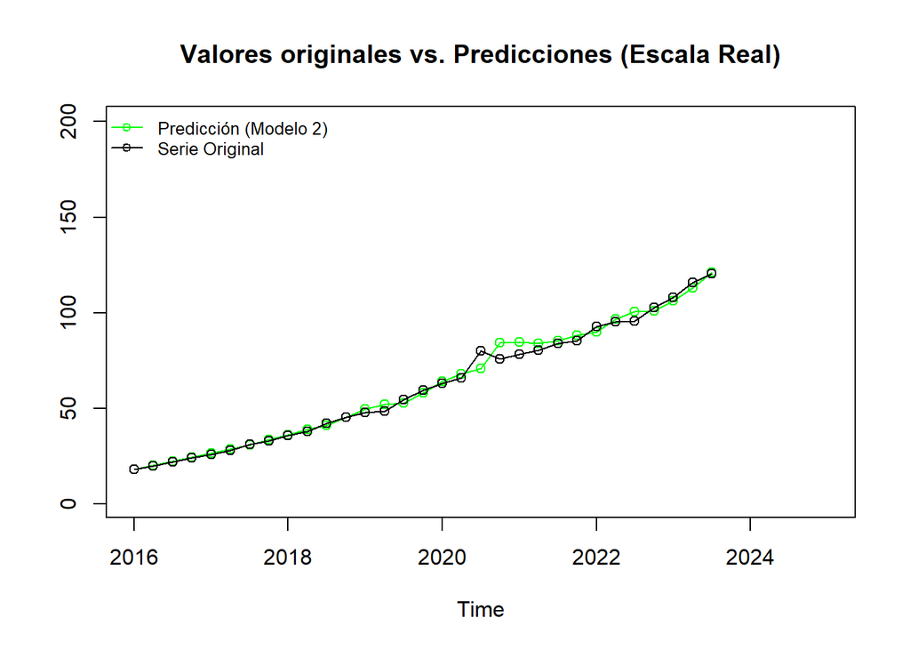

```r
# Gráfico de pronósticos intramuestra y valores originales

ts.plot(m2.predicted_insample.2, serie_original, col=c("green", "black"), type="o", ylim=c(1,200), xlim=c(2016,2025), main = "Valores originales vs. Predicciones (Escala Real)")

# Agregar la leyenda
legend("topleft",
       legend = c("Predicción (Modelo 2)", "Serie Original"),
       col = c("green", "black"),
       lty = 1,
       pch = 1,       # Añade el círculo (puntos) a la leyenda por el type="o"
       bty = "n",     # Quita el recuadro de la leyenda para que se vea más limpio
       cex = 0.8)     # Ajusta el tamaño del texto
```

```r
library(MLmetrics)
```

```r
## Mean Absolute Percentage Error Loss (%):
cat("\n\nMean Absolute Percentage Error Loss-MAPE(%):\n")
```

```
##
##
## Mean Absolute Percentage Error Loss-MAPE(%):
```

```r
MAPE <- MLmetrics::MAPE(m2.predicted_insample.2, serie_original)*100
MAPE
```

```
## [1] 3.05259
```

```r
## Error cuadrático medio (unidades originales)
cat("\n\nError cuadrático medio (RMSE):\n")
```

```
##
##
## Error cuadrático medio (RMSE):
```

```r
RMSE <- MLmetrics::RMSE(m2.predicted_insample.2, serie_original)
RMSE
```

```
## [1] 3.093235
```

```r
## Error absoluto medio:
cat("\n\nError Absoluto Medio (MAE):\n")
```

```
##
##
## Error Absoluto Medio (MAE):
```

```r
MAE <- MLmetrics::MAE(m2.predicted_insample.2, serie_original)
MAE
```

```
## [1] 2.104194
```

#### Período fuera de la muestra

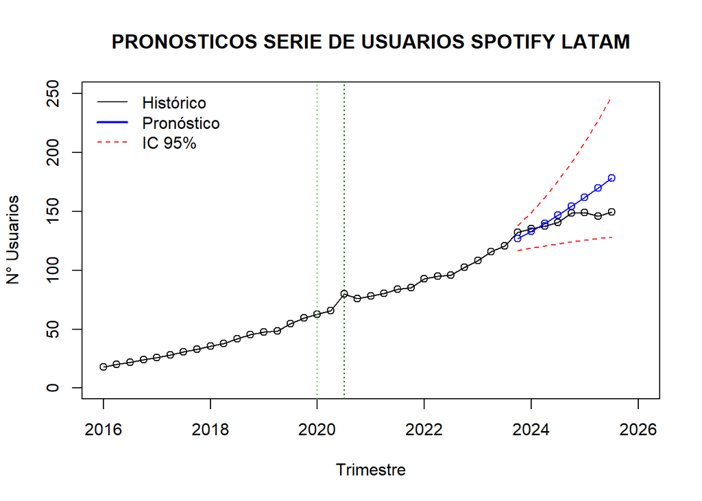

```r
# 1. Pronósticos en escala logarítmica
prod.pr = predict(modelo2, n.ahead=8)
s2 <- modelo2$sigma2 #Corrección de Jensen

# 2. Pronósticos y bandas de confianza en escala original
pred_original <- exp(prod.pr$pred + (s2 / 2))
U_original    <- exp((prod.pr$pred + 2 * prod.pr$se) + (s2 / 2))
L_original    <- exp((prod.pr$pred - 2 * prod.pr$se) + (s2 / 2))

# 3. Gráfico
ts.plot(usuarios_original_ts,pred_original, col=c("black", "blue"), type="o", ylim=c(1,250), xlim=c(2016,2026),
main="PRONOSTICOS SERIE DE USUARIOS SPOTIFY LATAM",ylab="N° Usuarios",xlab="Trimestre")
 lines(U_original, col="red", lty="dashed")
 lines(L_original, col="red", lty="dashed")
abline(v=2020,lty="dotted",col="11")

# 4. Leyenda del gráfico

abline(v = 2020.50, lty = "dotted", col = "darkgreen")
legend("topleft",
       legend = c("Histórico", "Pronóstico", "IC 95%"),
       col = c("black", "blue", "red"),
       lty = c(1, 1, 2),
       lwd = c(1, 2, 1),
       bty = "n")
```

```r
# Calcular el MAPE para el conjunto de prueba

cat("\n\nMean Absolute Percentage Error Loss-MAPE(%):\n")
```

```
##
##
## Mean Absolute Percentage Error Loss-MAPE(%):
```

```r
m2.MAPE_prueba <- MLmetrics::MAPE(pred_original, conjunto_prueba)*100
m2.MAPE_prueba
```

```
## [1] 7.45373
```

```r
## Error cuadrático medio (unidades originales)
cat("\n\nError cuadratico medio (RMSE):\n")
```

```
##
##
## Error cuadratico medio (RMSE):
```

```r
m2.RMSE_prueba <- MLmetrics::RMSE(pred_original, conjunto_prueba)
m2.RMSE_prueba
```

```
## [1] 14.46749
```

```r
## Error absoluto medio:
cat("\n\nError Absoluto Medio (MAE):\n")
```

```
##
##
## Error Absoluto Medio (MAE):
```

```r
m2.MAE_prueba <- MLmetrics::MAE(pred_original, conjunto_prueba)
m2.MAE_prueba
```

```
## [1] 10.88639
```

- En cuanto a los pronósticos fuera de muestra, se observa que la predicción muestra una tendencia estrictamente creciente, mientras que los datos observados decrecen a partir del 2025, probablemente por el aumento generalizado de las tarifas de suscripción [[https://www.elcolombiano.com/tecnologia/spotify-aumento-precio-premium-colombia-2025-NI28575923].](https://www.elcolombiano.com/tecnologia/spotify-aumento-precio-premium-colombia-2025-NI28575923%5D.)
- Esto se traduce en un MAPE del 7.45% y un MAE de 10.89 millones de usuarios.

### Pruebas al modelo 3

#### Período dentro de la muestra

```r
m3.predicted_log <- serie_log - modelo3$residuals
m3.predicted_log
```

```
##          Qtr1     Qtr2     Qtr3     Qtr4
## 2016 2.889500 2.996358 3.092043 3.179313
## 2017 3.261082 3.327323 3.413800 3.503938
## 2018 3.565314 3.641169 3.714721 3.801938
## 2019 3.881839 3.915879 3.964790 4.061214
## 2020 4.141105 4.186345 4.286895 4.444946
## 2021 4.373315 4.394278 4.478294 4.445778
## 2022 4.474841 4.552807 4.629020 4.572074
## 2023 4.663446 4.701172 4.812415
```

```r
# 2. Extraer la varianza del error (sigma^2) del modelo
s2 <- modelo3$sigma2

# 3. Aplicar transformación inversa con corrección de Jensen
# Fórmula: exp(log_pred + sigma^2 / 2)
m3.predicted_insample.2 <- round(exp(m3.predicted_log + (s2 / 2)), 2)
```

```r
# 1. Crear el índice y forzarlo a texto plano (UTF-8)
# Usamos paste0 para construir el texto manualmente y evitar caracteres extraños
tiempos <- time(serie_original)
anios <- floor(tiempos)
trimestres <- cycle(tiempos)
indice_limpio <- paste0(anios, "-T", trimestres)

# 2. Construir el data frame asegurando que sean vectores numéricos simples
m3.df_comparativo <- data.frame(
  Trimestre = as.character(indice_limpio),
  Real = round(as.numeric(serie_original), 2),
  Prediccion = round(as.numeric(m3.predicted_insample.2), 2),
  Diferencia = round(as.numeric(serie_original), 2) - round(as.numeric(m3.predicted_insample.2), 2),
  stringsAsFactors = FALSE
)

# 3. Generar la flextable
library(flextable)
ft <- flextable(m3.df_comparativo)
ft <- autofit(ft)
ft
```

| Trimestre | Real | Prediccion | Diferencia |
| --- | --- | --- | --- |
| 2016-T1 | 18.00 | 18.00 | 0.00 |
| 2016-T2 | 20.00 | 20.03 | -0.03 |
| 2016-T3 | 22.00 | 22.04 | -0.04 |
| 2016-T4 | 24.00 | 24.05 | -0.05 |
| 2017-T1 | 26.00 | 26.10 | -0.10 |
| 2017-T2 | 28.00 | 27.89 | 0.11 |
| 2017-T3 | 31.00 | 30.41 | 0.59 |
| 2017-T4 | 33.00 | 33.28 | -0.28 |
| 2018-T1 | 35.70 | 35.38 | 0.32 |
| 2018-T2 | 37.80 | 38.17 | -0.37 |
| 2018-T3 | 42.00 | 41.08 | 0.92 |
| 2018-T4 | 45.50 | 44.83 | 0.67 |
| 2019-T1 | 47.70 | 48.56 | -0.86 |
| 2019-T2 | 48.70 | 50.24 | -1.54 |
| 2019-T3 | 54.60 | 52.76 | 1.84 |
| 2019-T4 | 59.60 | 58.10 | 1.50 |
| 2020-T1 | 62.90 | 62.93 | -0.03 |
| 2020-T2 | 65.78 | 65.84 | -0.06 |
| 2020-T3 | 80.00 | 72.80 | 7.20 |
| 2020-T4 | 75.90 | 85.27 | -9.37 |
| 2021-T1 | 78.32 | 79.38 | -1.06 |
| 2021-T2 | 80.30 | 81.06 | -0.76 |
| 2021-T3 | 83.82 | 88.16 | -4.34 |
| 2021-T4 | 85.26 | 85.34 | -0.08 |
| 2022-T1 | 92.84 | 87.86 | 4.98 |
| 2022-T2 | 95.26 | 94.98 | 0.28 |
| 2022-T3 | 95.76 | 102.50 | -6.74 |
| 2022-T4 | 102.69 | 96.83 | 5.86 |
| 2023-T1 | 108.15 | 106.09 | 2.06 |
| 2023-T2 | 115.71 | 110.17 | 5.54 |
| 2023-T3 | 120.54 | 123.14 | -2.60 |

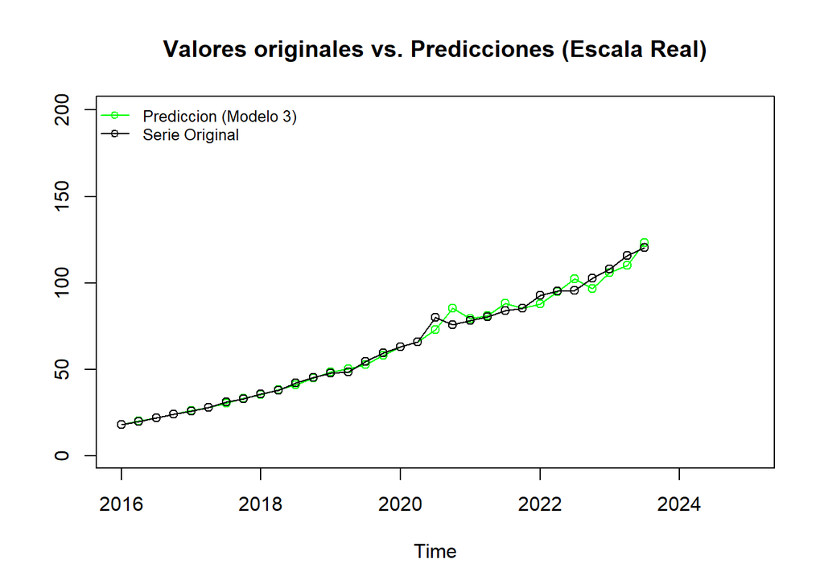

```r
# Gráfico de pronósticos intramuestra y valores originales

ts.plot(m3.predicted_insample.2, serie_original, col=c("green", "black"), type="o", ylim=c(1,200), xlim=c(2016,2025), main = "Valores originales vs. Predicciones (Escala Real)")

# Agregar la leyenda
legend("topleft",
       legend = c("Prediccion (Modelo 3)", "Serie Original"),
       col = c("green", "black"),
       lty = 1,
       pch = 1,       # Añade el círculo (puntos) a la leyenda por el type="o"
       bty = "n",     # Quita el recuadro de la leyenda para que se vea más limpio
       cex = 0.8)     # Ajusta el tamaño del texto
```

```r
library(MLmetrics)

## Mean Absolute Percentage Error Loss (%):
cat("\n\nMean Absolute Percentage Error Loss-MAPE(%):\n")
```

```
##
##
## Mean Absolute Percentage Error Loss-MAPE(%):
```

```r
MAPE <- MLmetrics::MAPE(m3.predicted_insample.2, serie_original)*100
MAPE
```

```
## [1] 2.47637
```

```r
## Error cuadrático medio (unidades originales)
cat("\n\nError cuadratico medio (RMSE):\n")
```

```
##
##
## Error cuadratico medio (RMSE):
```

```r
RMSE <- MLmetrics::RMSE(m3.predicted_insample.2, serie_original)
RMSE
```

```
## [1] 3.199097
```

```r
## Error absoluto medio:
cat("\n\nError Absoluto Medio (MAE):\n")
```

```
##
##
## Error Absoluto Medio (MAE):
```

```r
MAE <- MLmetrics::MAE(m3.predicted_insample.2, serie_original)
MAE
```

```
## [1] 1.94129
```

- De acuerdo con lo observado en el gráfico, el modelo N°3 sobreestima los valores de la serie de entrenamiento especialmente en el año 2020, con diferencias de hasta 9 millones de usuarios por encima del valor observado en 2020-IV. Sin embargo, se observa que en varios trimestres, la diferencia es de menos de 1 millón de usuarios.
- Esto se traduce en un MAPE del 2.47% y un MAE de 1.94 millones de usuarios.

#### Período fuera de la muestra

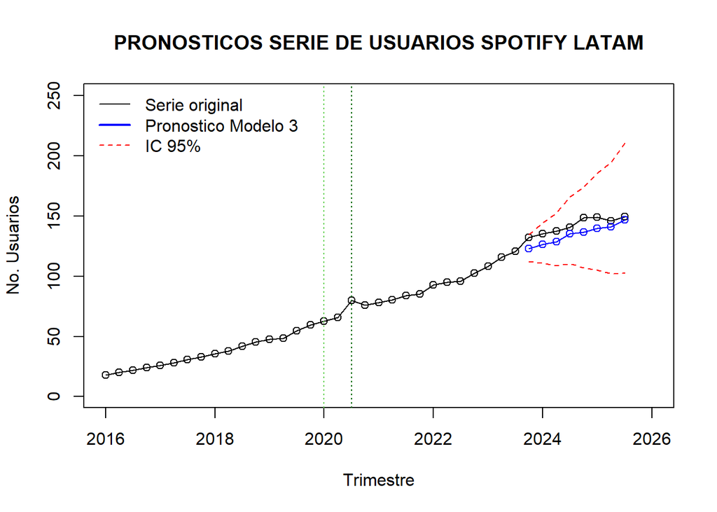

```r
# 1. Pronósticos en escala logarítmica
m3.prod.pr = predict(modelo3, n.ahead=8)
s2 <- modelo3$sigma2 #Corrección de Jensen

# 2. Pronósticos y bandas de confianza en escala original
m3.pred_original <- exp(m3.prod.pr$pred + (s2 / 2))
m3.U_original    <- exp((m3.prod.pr$pred + 2 * m3.prod.pr$se) + (s2 / 2))
m3.L_original    <- exp((m3.prod.pr$pred - 2 * m3.prod.pr$se) + (s2 / 2))

# 3. Gráfico
ts.plot(usuarios_original_ts, m3.pred_original, col=c("black", "blue"), type="o", ylim=c(1,250), xlim=c(2016,2026),
main="PRONOSTICOS SERIE DE USUARIOS SPOTIFY LATAM",ylab="No. Usuarios",xlab="Trimestre")
 lines(m3.U_original, col="red", lty="dashed")
 lines(m3.L_original, col="red", lty="dashed")
abline(v=2020,lty="dotted",col="11")

# 4. Leyenda del gráfico

abline(v = 2020.50, lty = "dotted", col = "darkgreen")
legend("topleft",
       legend = c("Serie original", "Pronostico Modelo 3", "IC 95%"),
       col = c("black", "blue", "red"),
       lty = c(1, 1, 2),
       lwd = c(1, 2, 1),
       bty = "n")
```

```r
# Calcular el MAPE para el conjunto de prueba

cat("\n\nMean Absolute Percentage Error Loss-MAPE(%):\n")
```

```
##
##
## Mean Absolute Percentage Error Loss-MAPE(%):
```

```r
m3.MAPE_prueba <- MLmetrics::MAPE(m3.pred_original, conjunto_prueba)*100
m3.MAPE_prueba
```

```
## [1] 5.467609
```

```r
## Error cuadrático medio (unidades originales)
cat("\n\nError cuadratico medio (RMSE):\n")
```

```
##
##
## Error cuadratico medio (RMSE):
```

```r
m3.RMSE_prueba <- MLmetrics::RMSE(m3.pred_original, conjunto_prueba)
m3.RMSE_prueba
```

```
## [1] 8.225879
```

```r
## Error absoluto medio:
cat("\n\nError Absoluto Medio (MAE):\n")
```

```
##
##
## Error Absoluto Medio (MAE):
```

```r
m3.MAE_prueba <- MLmetrics::MAE(m3.pred_original, conjunto_prueba)
m3.MAE_prueba
```

```
## [1] 7.740514
```

- En cuanto a los pronósticos fuera de muestra, se observa que la predicción se acerca más a la tendencia decreciente de los datos observados decrecen a partir del 2025, probablemente por el aumento generalizado de las tarifas de suscripción [[https://www.elcolombiano.com/tecnologia/spotify-aumento-precio-premium-colombia-2025-NI28575923].](https://www.elcolombiano.com/tecnologia/spotify-aumento-precio-premium-colombia-2025-NI28575923%5D.)
- Esto se traduce en un MAPE del 5.46% y un MAE de 7.74 millones de usuarios.

## Resumen de resultados

Resultados:

[output not shown]

**Problemas encontrados:**

- Las transformaciones previas que se intentaron con la serie original (logaritmo natural y transformación de Box-Cox) no mostraron mayor diferencia entre sí sobre los valores de la varianza de la serie. Finalmente se optó por trabajar la serie en logaritmo por facilidad en la interpretación.
- Si bien el uso de sólo 1 diferencia ordinaria era la que arrojaba una menor desviación estándar, los correlogramas dejaban de mostrar valores significativos de autocorrelación. Por esta razón, se optó en principio por el uso de dos diferencias ordinarias.
- Los criterios de información arrojaban la peor calificación para el modelo N° 3 debido a su complejidad, pero este fue el de mayor poder de predicción.
- Los modelos N° 2 y 3 tuvieron un desempeño casi idéntico en el conjunto de entrenamiento, por lo que la decisión final se tomó con base en el poder de predicción fuera de la muestra.